# Tugas UTS

Angga Fathan Rofiqy

02 March, 2024

# Resampling Jackknife

## Pendahuluan

Proses **pendugaan parameter** selalu didasari dengan **asumsi sebaran** dan **ukuran contoh** yang memadai. **Asumsi sebaran** ini menjadi dasar penentuan **selang kepercayaan** bagi parameter (misal 𝜇). Selang kepercayaan bagi 𝜇 juga **bisa diperoleh** meskipun **contoh acak berukuran kecil** tetapi kita mengasumsikan populasinya memiliki **sebaran Normal**. Seandainya contoh acak berukuran kecil dan sebaran populasinya tidak diketahui, selang kepercayaan bagi parameter **tidak bisa diperoleh** tanpa sebaran.

Contoh acak **berukuran kecil** tidak jarang diperoleh dan bahkan **tidak ada informasi** tentang **sebarannya**. Pendugaan selang bagi parameter harus dengan metode yang didasarkan pada asumsi sebaran. Sebaran populasi data tidak diketahui sehingga kita tidak mempunyai dasar yang kuat untuk menduga selang kepecayaan tanpa sebaran.

> Jadi inti permasalahan nya adalah ketika n berukuran kecil, karena:
- Ukuran **n kecil** mengakibatkan beberapa **teori peluang** dan **statistika inferensia** **tidak terpenuhi**.
- Ukuran **n kecil** juga menjadi per**masalah**an dalam suatu **pendugaan parameter** yang berkaitan dengan **tingkat keakuratan dan ketelitian**.
- Ukuran **n kecil** mengakibatkan Tidak adanya informasi mengenai sebaran populasi.
- Ukuran **n kecil** memiliki masalah dalam Pengujian Hipotesis.

> **Jackknife** dapat digunakan sebagai cara **pendugaan selang** dalam kondisi **data berukuran kecil** dan **tidak memenuhi asumsi sebaran**.

Sama seperti metode bootstrap, Ide dasar dari jackknife adalah **membangun data semu** dengan menggunakan informasi data asli. Sehingga kita bisa memperoleh **n** yang lebih **besar**. Metode ini menjadi sebuah metode yang efisien untuk mendapatkan **hasil yang robust**.

Metode Jackknife menggunakan **partisi sistematis** dari kumpulan data untuk **mengestimasi properti** dari **estimator** dihitung dari **sampel penuh**. Quenouille (1949, 1956) menyarankan teknik untuk memperkirakan (dan, karenanya, **mengurangi**) **bias** dari suatu penduga. Tukey (1958) menciptakan istilah **pisau lipat** untuk merujuk pada metode, dan juga menunjukkan bahwa metode tersebut berguna dalam **mengestimasi varian** dari suatu penduga.

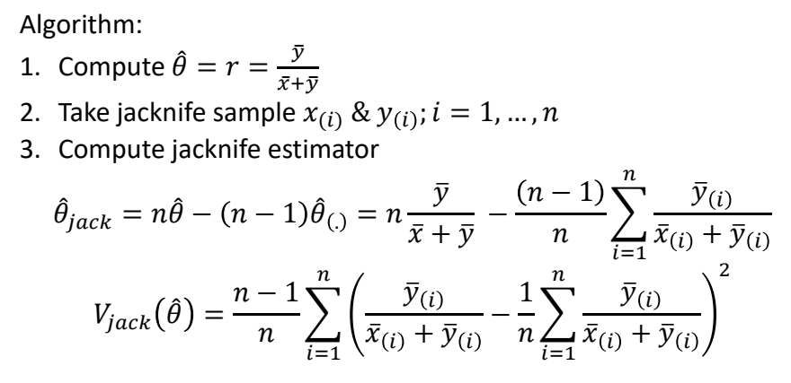

### Tujuan

Pada awalnya metode jackknife atau leave-one-out **bertujuan** untuk **menduga bias** dari suatu penduga yang diperkenalkan oleh Maurice Quenouille pada tahun 1949 dan dikembangkan oleh John Tukey pada tahun 1957, yang dikenal dengan Quenouille-Tukey Jackknife. Metode jackknife **serupa** dengan metode **bootstrap** untuk **galat baku**. Metode ini **seperti tipe validasi silang leave-one-out**. Bila 𝒙=(𝑥1, 𝑥2, …, 𝑥𝑛) adalah contoh acak dan 𝒙((𝒊)) adalah subset dari 𝒙 tanpa pengamatan 𝑥𝑖, yaitu 𝒙((𝒊))=(𝑥1, …,𝑥((𝑖−1) ), 𝑥((𝑖+1) ), …, 𝑥𝑛). Jika 𝜃 duga=𝑓𝑛 (𝒙), maka definisikan bahwa 𝜃 duga=𝑓(𝑛−1) ( 𝒙((𝒊) ) ), 𝑖=1, 2, …, 𝑛.

# Data

## Data Input

```r
raw.data <- read.csv("Data PSD.csv")
data <- raw.data[-nrow(raw.data), c("BJR","BB")] %>% as.data.frame()

datatable(raw.data, filter = 'top',
          options = list(pageLength = 5))
```

|  | Provinsi | Gada | KG | KH | GM | APB | GPL | TSN | GB | BJR | BB | TL |
| --- | --- | --- | --- | --- | --- | --- | --- | --- | --- | --- | --- | --- |
| 1 | ACEH | 4406 | 173 | 43 | 1 | 108 | 106 | 2 | 493 | 1435 | 81 | 198 |
| 2 | SUMATERA UTARA | 3827 | 127 | 59 | 82 | 483 | 78 | 4 | 964 | 732 | 52 | 483 |
| 3 | SUMATERA BARAT | 513 | 43 | 18 | 0 | 248 | 57 | 0 | 364 | 342 | 65 | 222 |
| 4 | RIAU | 1224 | 51 | 194 | 0 | 53 | 15 | 0 | 0 | 455 | 1 | 21 |
| 5 | JAMBI | 1001 | 16 | 16 | 0 | 44 | 2 | 0 | 36 | 476 | 17 | 57 |
| 6 | SUMATERA SELATAN | 2644 | 98 | 64 | 0 | 90 | 3 | 0 | 49 | 380 | 36 | 103 |
| 7 | BENGKULU | 1195 | 19 | 4 | 0 | 17 | 14 | 0 | 66 | 171 | 15 | 81 |
| 8 | LAMPUNG | 2093 | 30 | 11 | 0 | 158 | 35 | 0 | 47 | 328 | 23 | 70 |
| 9 | KEP. BANGKA BELITUNG | 265 | 0 | 14 | 0 | 77 | 17 | 0 | 0 | 59 | 0 | 1 |
| 10 | KEP. RIAU | 241 | 27 | 57 | 0 | 40 | 69 | 0 | 0 | 61 | 1 | 25 |

[output cut: 25 more lines]

## Data Checking

> Tipe Data

```r
str(data)
```

```
## 'data.frame':    34 obs. of  2 variables:
##  $ BJR: int  1435 732 342 455 476 380 171 328 59 61 ...
##  $ BB : int  81 52 65 1 17 36 15 23 0 1 ...
```

Tipe Data sudah sesuai.

> Missing Value

```r
colSums(is.na(data))
```

```
## BJR  BB
##   0   0
```

## Data Exploration

Tidak ada data kosong.

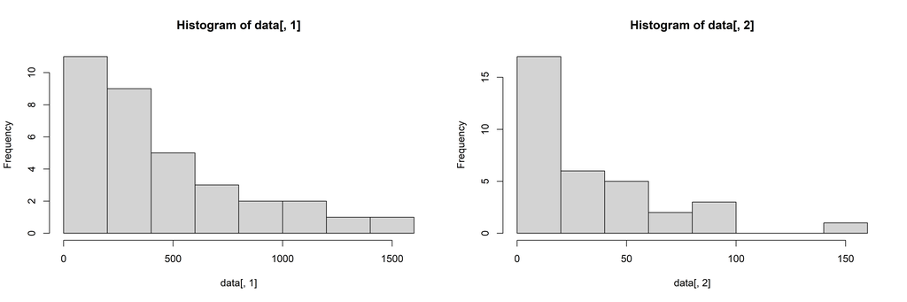

```r
par(mfrow=c(1,2))
hist(data[,1]); hist(data[,2])
```

Dalam konteks analisis jackknife, penting untuk mempertimbangkan bagaimana distribusi awal data dapat mempengaruhi estimasi parameter dan variabilitasnya. Walau jackknife bisa mengurangi bias dan memberikan estimasi varians yang robust, distribusi data yang sangat menyimpang dari normalitas bisa mempengaruhi keakuratan dari metode ini.

```r
n <- nrow(data)
#1. Hitung Teta Duga
teta_hat <- mean(data[,1])/ ( mean(data[,1]) +mean(data[,2]) )

#2. Jacknife Sampling
x1 <- matrix(NA, n, n-1)
x2 <- matrix(NA, n, n-1)
for (i in 1:n) {
  x1[i,] <- data[,1][-i]
  x2[i,] <- data[,2][-i]
}
x1bar <- apply(x1, 1, mean)
x2bar <- apply(x2, 1, mean)

#3. Menghitung Jacknife Estimator
teta_i <- x1bar/ (x2bar +x1bar)
teta_jk <- n *teta_hat -(n-1) *mean(teta_i)
var_jk <- (n-1)/ n *sum( (teta_i - mean(teta_i))^2 )
se_jk <- sqrt(var_jk)
teta_jk; var_jk; se_jk
```

```
## [1] 0.9336889
```

```
## [1] 8.320111e-05
```

```
## [1] 0.009121464
```

```r
par(mfrow=c(2,2))
hist(data[,1]); hist(data[,2])
hist(x1); hist(x2)
```

[figure not shown]

Estimasi parameter yang diinginkan adalah 0.9336889, ini berarti proporsi target adalah sekitar 93.37%. Varians dan kesalahan standar yang relatif kecil (8.320111e-05 dan 0.009121464, secara berurutan) mengindikasikan bahwa estimasi parameter yang dihasilkan cukup stabil dan memiliki ketidakpastian yang rendah, setidaknya menurut sampel data yang Anda miliki.